# L2_Math_LA slides

## AERSP 597 - Machine Learning in Aerosapce Engineering

## Lecture 2, Math Background: Linear Algebra

### Instructor: Daning Huang

## TODAY: Quick (re)view of linear algebra

- Vectors and Matrices
- Eigenvalue decomposition
- Singular value decomposition (SVD)

### References:

- [Kreyszig] Chap. 7-8
- [PRML] Appendix C
- [Matrix Norms](https://www.cis.upenn.edu/~cis515/cis515-11-sl4.pdf)

## Vector norms

- Perhaps the most common norm is the Euclidean norm $$ \|x\|_2 := \sqrt{x_1^2 + x_2^2 + \ldots x_n^2}$$
- This is a special case of the $p$-norm: $$ \|x\|_p := \left(|x_1|^p + \ldots + |x_n|^p\right)^{1/p}$$
- Special cases: $p=1$ and $p=0$? $$ \|x\|_1\ \mbox{Sum of absolute values},\quad \|x\|_0\ \mbox{Number of non-zeros} $$
- There's also the so-called **infinity norm** $$ \|x\|_\infty := \max_{i=1,\ldots, n} |x_i|$$
- A vector $x$ is said to be *normalized* if $\|x\| = 1$

### Geometrical interpretation

In 2D, when $\|x\|=1$, what is the shape of curve?

[figure not shown]

## Matrix norms

- Simple extension from vector norms - think a $m\times n$ matrix as a $mn$-dimensional vector
  - For example, Frobenius norm $$ \|A\|_F := \left( \sum_{i,j} A_{ij}^2 \right)^{1/2} $$
- Induced norms from vector norms $$ \|A\|_p := \max_{\|x\|_p=1}\|Ax\|_p $$

## Orthogonal + Normalized = Orthonormal

- Two vectors $x,y$ are *orthogonal* if $x^T y = 0$
- A square matrix $U \in \mathbb{R}^{n \times n}$ is *orthogonal* if all columns $u_1, \ldots, u_n$ are orthogonal to each other (i.e. $u_i^\top u_j = 0$ for $i \ne j$)
- $U$ is *orthonormal* if it is orthogonal **and** the columns are normalized, i.e. $\|u_i\|_2 = 1$ for every $i$.
- $U$ forms an orthonormal basis of the $\mathbb{R}^n$ vector space.

### Orthonormal matrix for projection

- $U\in \mathbb{R}^{n\times m}$ column-wise orthonormal, i.e. $U^\top U=I_m$
- Then $U$ form the orthonormal basis of a $m$-dimensional subspace $S$ in $\mathbb{R}^n$
  - e.g. 2D plane in 3D space
- The component $p$ of a $n$-dimensional vector $v$ in subspace $S$ is given by the projection $ p=UU^\top v $
- The residual is $r = v-p = (I-UU^\top)v$ and orthogonal to $p$
  - Or - the residual does not carry any information concerning the subspace

[figure not shown]

## Positive Definiteness

- We say a symmetric matrix $A$ is positive definite if $$ x^\top A x > 0 \text{ for all } x \ne 0$$
- We say a matrix is positive semi-definite (PSD) if $$ x^\top A x \geq 0 \text{ for all } x$$
- A matrix that is positive definite gives us a *norm*. Let $$ \| x \|_A := \sqrt{x ^\top A x} $$

## Visualization of PD matrices

Contour plots of $f(x)=x^TAx$, starting with -

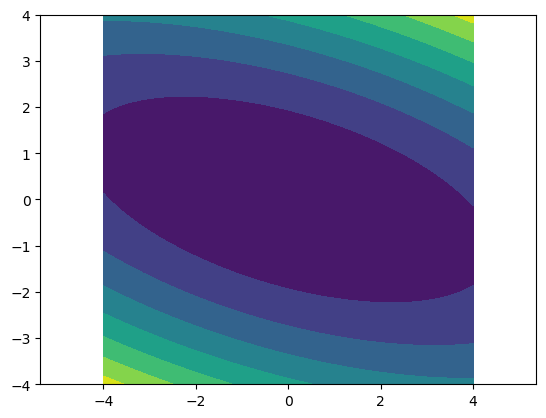

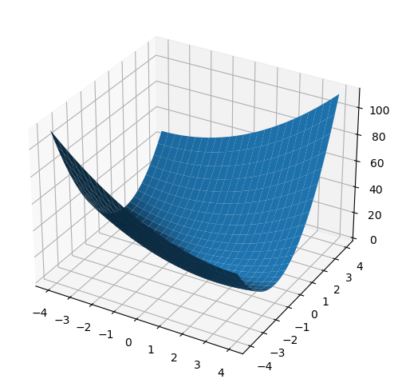

```python
A = np.array([
    [1,1],
    [1,4]])
pltPSD(A, with_eig=False, if3d=False)
pltPSD(A, with_eig=False, if3d=True)
```

## Eigenvalues and Eigenvectors

### What are eigenvectors?

- A Matrix is a mathematical object that acts on a (column) vector, resulting in a new vector, i.e. $Ax=b$
- An eigenvector is the resulting vector that is parallel to $x$ (some multiple of $x$) $$ {A}x=\lambda x $$
- The eigenvectors with an eigenvalue of zero are the vectors in the nullspace
- If A is singular (takes some non-zero vector into 0) then $\lambda=0$

## Numerical example

```python
X = np.array([[3, 1], [1, 3]])
Matrix(X)
```

$\displaystyle \left[\begin{matrix}3 & 1\\1 & 3\end{matrix}\right]$

```python
eigenvals, eigenvecs = np.linalg.eig(X)
Matrix(eigenvecs)
```

$\displaystyle \left[\begin{matrix}0.707106781186547 & -0.707106781186547\\0.707106781186547 & 0.707106781186547\end{matrix}\right]$

```python
newX = eigenvecs.dot(np.diag(eigenvals)).dot(eigenvecs.T)
Matrix(newX)
```

$\displaystyle \left[\begin{matrix}3.0 & 1.0\\1.0 & 3.0\end{matrix}\right]$

## Trace related to eigenvals

- Let $A$ be a matrix whose eigenvalues are $\lambda_1, \ldots, \lambda_n$
- Then we have the trace of satisfying $$\text{tr}(A) = \sum_{i=1}^n \lambda_i$$

```python
X = np.random.randn(5,10)
A = X.dot(X.T) # For fun, let's look at A = X * X^T
eigenvals, eigvecs = np.linalg.eig(A) # Compute eigenvalues of A
sum_of_eigs = sum(eigenvals) # Sum the eigenvalues
trace_of_A = A.trace() # Look at the trace
(sum_of_eigs, trace_of_A) # Are they the same?
```

$\displaystyle \left( 34.5438106270753, \ 34.5438106270753\right)$

## Determinant related to eigenvals

- Let $A$ be a matrix whose eigenvalues are $\lambda_1, \ldots, \lambda_n$
- Then we have the trace of satisfying $$|A| = \prod_{i=1}^n \lambda_i$$

```python
# We'll use the same matrix A as before
prod_of_eigs = np.prod(eigenvals) # Sum the eigenvalues
determinant = np.linalg.det(A) # Look at the trace
(prod_of_eigs, determinant) # Are they the same?
```

$\displaystyle \left( 1730.35765410988, \ 1730.35765410988\right)$

## Eigenvalue Decomposition

- Let $A$ be a matrix whose eigenvalues are $\lambda_1, \ldots, \lambda_n$ $$\Lambda=Diag([\lambda_1, \ldots, \lambda_n])$$
- And the corresponding eigenvectors are $x_1, \ldots, x_n$ $$X=[x_1, \ldots, x_n]$$
- Then we have the following decomposition $$ A=X\Lambda X^{-1} $$
- Further if $X$ is orthonormal, i.e. $X^{-1}=X^\top$, $$ A=\sum_{i=1}^n \lambda_i x_i x_i^\top $$
- Round back to visualization

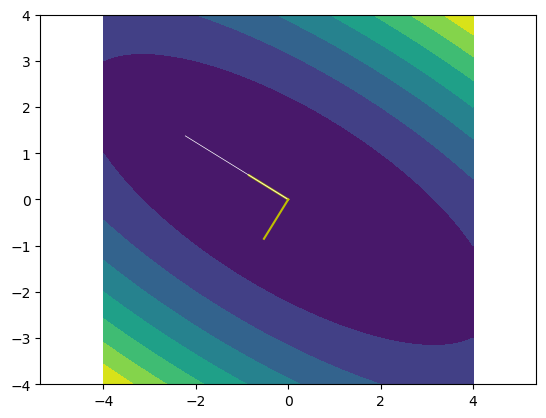

```python
A = np.array([
    [1,1],
    [1,2]])
pltPSD(A, with_eig=True, if3d=False)
```

## Singular Value Decomposition

- Not all square matrices can do eigenvalue decomposition - but
- Any matrix (symmetric, non-symmetric, etc.) $A \in \mathbb{R}^{n\times m}$ admits a *singular value decomposition* (SVD)
- The decomposition has three factors, $U \in \mathbb{C}^{n \times n}$, $\Sigma \in \mathbb{R}^{n \times m}$, and $V \in \mathbb{C}^{m \times m}$ $$A = U \Sigma V^*$$
- $U$ and $V$ are both orthonormal matrices, and $\Sigma$ is diagonal. $V^*$ indicates **conjugate transpose**.

[figure not shown]

## SVD Example

```python
A = np.array([[4, 4], [-3, 3]])
Matrix(A)
```

$\displaystyle \left[\begin{matrix}4 & 4\\-3 & 3\end{matrix}\right]$

- Let's show Sigma from the SVD output

```python
U, Sigma_diags, V = np.linalg.svd(A)
Matrix(np.diag(Sigma_diags)) # Numpy's SVD only returns diagonals, here I'm showing full Sigma
```

$\displaystyle \left[\begin{matrix}5.65685424949238 & 0\\0 & 4.24264068711928\end{matrix}\right]$

- And we can show the orthonormal bases $U$ and $V$

```python
Matrix(U), Matrix(V) # I rounded the values for clarity
```

$\displaystyle \left( \left[\begin{matrix}-1.0 & 0\\0 & 1.0\end{matrix}\right], \ \left[\begin{matrix}-0.70711 & -0.70711\\-0.70711 & 0.70711\end{matrix}\right]\right)$

## Properties of the SVD

*For simplicity, let's assume everything is real; then conjugate transpose is just transpose.*

$$\text{SVD:} \quad \quad A = U \Sigma V^\top$$

- The *singular values* of $A$ are the diagonal elements of $\Sigma$
- The singular values of $A$ are the *square roots of the eigenvalues* of both $A^\top A$ and $A A^\top$
- The *left-singular vectors* of $A$, i.e. the columns of $U$, are the *eigenvectors* of $A A^\top$
- The *right-singular vectors* of $A$, i.e. the columns of $V$, are the *eigenvectors* of $A^\top A$

Also - $\|A\|_2 = \sigma_\max(A)$, $\|A\|_F = (\sum_{i=1}^n \sigma_i^2)^{1/2}$

- An analogy to eigenvalue decomposition - but applicable to **all** matrices $$ A=\sum_{i=1}^{n} \sigma_iu_iv_i^\top $$
- Common trick to truncate and approximate a matrix - say the last $m$ $\sigma$'s are close to zero

$$ A\approx\sum_{i=1}^{n-m} \sigma_iu_iv_i^\top := \hat{A} $$

- Error estimate

$$ \frac{\|A-\hat{A}\|_F^2}{\|A\|_F^2} = \frac{\sum_{i=n-m+1}^{n}\sigma_i^2}{\sum_{i=1}^{n}\sigma_i^2} $$

- What is the implication in (1) subspace projection and (2) data compression?

[figure not shown]

## Simple application of SVD: Condition number

Consider two sets of linear equations $$ \begin{bmatrix} 3 & 1 \\ -3.0001 & 1 \end{bmatrix} \begin{bmatrix} x_1 \\ x_2 \end{bmatrix} = \begin{bmatrix} 4 \\ 4.0001 \end{bmatrix} $$

$$ \begin{bmatrix} 3 & 1 \\ -2.9999 & 1 \end{bmatrix} \begin{bmatrix} x_1 \\ x_2 \end{bmatrix} = \begin{bmatrix} 4 \\ 4.0002 \end{bmatrix} $$

How different are their solutions?

```python
A1=np.array([
    [3,1],
    [-3.0001,1]])
b1=np.array([4,4.0001])

A2=np.array([
    [3,1],
    [-2.9999,1]])
b2=np.array([4,4.0002])

x1=np.linalg.solve(A1,b1)
x2=np.linalg.solve(A2,b2)

print(x1)
print(x2)
```

```
[-1.66663889e-05  4.00005000e+00]
[-3.33338889e-05  4.00010000e+00]
```

Consider another two sets of linear equations - note the signs $$ \begin{bmatrix} 3 & 1 \\ 3.0001 & 1 \end{bmatrix} \begin{bmatrix} x_1 \\ x_2 \end{bmatrix} = \begin{bmatrix} 4 \\ 4.0001 \end{bmatrix} $$

$$ \begin{bmatrix} 3 & 1 \\ 2.9999 & 1 \end{bmatrix} \begin{bmatrix} x_1 \\ x_2 \end{bmatrix} = \begin{bmatrix} 4 \\ 4.0002 \end{bmatrix} $$

How different are their solutions?

```python
B1=np.array([
    [3,1],
    [3.0001,1]])
b1=np.array([4,4.0001])

B2=np.array([
    [3,1],
    [2.9999,1]])
b2=np.array([4,4.0002])

y1=np.linalg.solve(B1,b1)
y2=np.linalg.solve(B2,b2)

print(y1)
print(y2)
```

```
[1. 1.]
[-2. 10.]
```

Condition number of a matrix, $\kappa(A)$: How much the solution $x$ would change with respect to a change in $b$.

$$ \kappa(A) = \|A\|\|A^{-1}\| = \frac{\sigma_\max(A)}{\sigma_\min(A)} $$

```python
print(np.linalg.cond(A1))
print(np.linalg.cond(B1))
```

```
3.0000500009374806
200006.00009591616
```

Special algorithms are needed to solve linear systems with ill-conditioned matrices!

- We will cover some of these algorithms later (LU, Cholesky, and QR decomposition)